# *Import Important libraries*

```python
import warnings
warnings.filterwarnings('ignore')
```

```python
import pandas as pd
import plotly.express as px
import numpy as np
import seaborn as sns
from datetime import datetime
import matplotlib.pyplot as plt
from sklearn.preprocessing import StandardScaler
from sklearn.model_selection import train_test_split
from sklearn.linear_model import LinearRegression
from sklearn.preprocessing import OneHotEncoder
from sklearn.tree import DecisionTreeRegressor
from sklearn.ensemble import RandomForestRegressor
from sklearn.ensemble import RandomForestClassifier
from sklearn.metrics import mean_squared_error,mean_absolute_error
from sklearn.svm import SVC
from sklearn.svm import SVR
from sklearn.metrics import accuracy_score
from sklearn.linear_model import LogisticRegression
import sklearn.metrics as metrics
from sklearn.linear_model import Ridge
from sklearn.linear_model import Lasso
from sklearn import linear_model
from sklearn.naive_bayes import GaussianNB
from sklearn.model_selection import RandomizedSearchCV
from sklearn.model_selection import GridSearchCV

from sklearn.feature_selection import SelectKBest,RFE
from xgboost import XGBRegressor
from xgboost import XGBClassifier
from sklearn.metrics import confusion_matrix
from sklearn.metrics import classification_report
from sklearn.model_selection import KFold,cross_val_score
%matplotlib inline
```

# *Explore Dataset*

```python
CVD=pd.read_excel("covid2.xls")
CVD.drop(columns="Unnamed: 0",inplace=True)
```

### Change Date into Day and Month format

```python
CVD['Date'] =pd.to_datetime(CVD['Date'], infer_datetime_format=True)
CVD['Month']=CVD['Date'].dt.month
CVD['Day']=CVD['Date'].dt.day
CVD.drop(columns='Date',inplace=True)
CVD
```

|  | Confirmed_cases | Deaths_cases | Recovered_cases | Travel_history | Province | City | Active_cases | Month | Day |
| --- | --- | --- | --- | --- | --- | --- | --- | --- | --- |
| 0 | 1 | 0 | 0 | China | Islamabad_Capital_Territory | Islamabad | 1 | 2 | 26 |
| 1 | 2 | 0 | 0 | Iran_Taftan | Sindh | Karachi | 2 | 2 | 26 |
| 2 | 1 | 0 | 0 | China | Islamabad_Capital_Territory | Islamabad | 1 | 2 | 29 |
| 3 | 1 | 0 | 0 | Iran_Taftan | Sindh | Karachi | 1 | 2 | 29 |
| 4 | 1 | 0 | 0 | Iran_Taftan | Gilgit_Baltistan | Gilgit | 1 | 3 | 2 |
| ... | ... | ... | ... | ... | ... | ... | ... | ... | ... |
| 2349 | 5 | 1 | 0 | Local_Social_Contact | Azad_Jummu_Kashmir | Muzaffarabad | 4 | 5 | 27 |
| 2350 | 8 | 0 | 0 | Local_Social_Contact | Azad_Jummu_Kashmir | Muzaffarabad | 8 | 5 | 28 |
| 2351 | 7 | 1 | 6 | Local_Social_Contact | Azad_Jummu_Kashmir | Muzaffarabad | 0 | 5 | 29 |
| 2352 | 16 | 0 | 2 | Local_Social_Contact | Azad_Jummu_Kashmir | Muzaffarabad | 14 | 6 | 1 |
| 2353 | 13 | 1 | 0 | Local_Social_Contact | Azad_Jummu_Kashmir | Muzaffarabad | 12 | 6 | 2 |

2354 rows × 9 columns

# *Model Development*

Developing models for the dataset is an imporatnt stage of machine learning.Various techniques used for model development such as Regression and Classification techniques etc. In my data set i will use both Regression and classification in different perspective.Firstly i will develop model for Regression technique.

## Regression Evaluation Metrics¶

Here are three common evaluation metrics for regression problems:

- Mean Absolute Error (MAE) is the mean of the absolute value of the errors
- Mean Squared Error (MSE) is the mean of the squared errors
- Root Mean Squared Error (RMSE) is the square root of the mean of the squared errors

### Comparing these metrics:

- MAE is the easiest to understand, because it's the average error.
- MSE is more popular than MAE, because MSE "punishes" larger errors, which tends to be useful in the real world.
- RMSE is even more popular than MSE, because RMSE is interpretable in the "y" units

```python
from sklearn import metrics
from sklearn.model_selection import cross_val_score

def cross_val(model,X,y):
    pred = cross_val_score(model, X, y, cv=10)
    return pred.mean()






def evaluate(true, predicted):
    mae = metrics.mean_absolute_error(true, predicted)
    mse = metrics.mean_squared_error(true, predicted)
    rmse = np.sqrt(metrics.mean_squared_error(true, predicted))
    r2_square = metrics.r2_score(true, predicted)

    return mae, mse, rmse, r2_square
```

```python
Test_Accuracy=[]
RegModel=[]
Train_accuracy=[]
```

## *Simple Linear Regression*

### 1). First method to take only province

As our dataset contains categorical features so it is necessary to convert categorical features into numerical data.To perform this task i am using One Hot Encoding technique.

```python
cv=CVD[['Province','Active_cases']]
dv1=pd.get_dummies(cv,drop_first=True)
dv1
```

|  | Active_cases | Province_Baluchistan | Province_Federal_Administration_Tribal_Area | Province_Gilgit_Baltistan | Province_Islamabad_Capital_Territory | Province_Khyber_Pakhtunkhwa | Province_Punjab | Province_Sindh |
| --- | --- | --- | --- | --- | --- | --- | --- | --- |
| 0 | 1 | 0 | 0 | 0 | 1 | 0 | 0 | 0 |
| 1 | 2 | 0 | 0 | 0 | 0 | 0 | 0 | 1 |
| 2 | 1 | 0 | 0 | 0 | 1 | 0 | 0 | 0 |
| 3 | 1 | 0 | 0 | 0 | 0 | 0 | 0 | 1 |
| 4 | 1 | 0 | 0 | 1 | 0 | 0 | 0 | 0 |
| ... | ... | ... | ... | ... | ... | ... | ... | ... |
| 2349 | 4 | 0 | 0 | 0 | 0 | 0 | 0 | 0 |
| 2350 | 8 | 0 | 0 | 0 | 0 | 0 | 0 | 0 |
| 2351 | 0 | 0 | 0 | 0 | 0 | 0 | 0 | 0 |
| 2352 | 14 | 0 | 0 | 0 | 0 | 0 | 0 | 0 |
| 2353 | 12 | 0 | 0 | 0 | 0 | 0 | 0 | 0 |

2354 rows × 8 columns

```python
X=dv1.drop(columns='Active_cases')
y=dv1['Active_cases']
```

### *Correlation between target variable and (Active cases)*

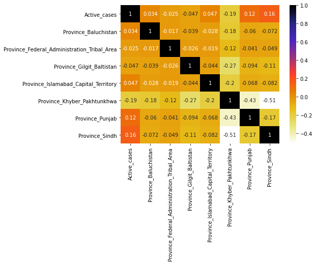

```python
Corelation = dv1.corr()
Corelation
top_fatures = Corelation.index
plt.figure(figsize = (7 , 5))
g = sns.heatmap(dv1[top_fatures].corr() , annot = True , cmap ='CMRmap_r')
```

### Train and Test Data

```python
X_train_confirmed, X_test_confirmed, y_train_confirmed, y_test_confirmed = train_test_split(X, y, test_size=0.3,shuffle=True,random_state=50)
```

### Fit Linear Regression Model

```python
L1=LinearRegression()
L1.fit(X_train_confirmed,y_train_confirmed)
```

```
LinearRegression()
```

```python
pre1=L1.predict(X_test_confirmed)
```

```python
df = pd.DataFrame(data=y_test_confirmed)
df1 = pd.DataFrame(data=pre1)
df1.index = df.index

dff=pd.concat([df,df1],axis=1,ignore_index=False)
dff.columns=['Actual','Predicted']
dff
```

|  | Actual | Predicted |
| --- | --- | --- |
| 467 | 91 | 48.271777 |
| 1674 | 2 | 6.896627 |
| 917 | 5 | 6.896627 |
| 1158 | 3 | 6.896627 |
| 499 | 4 | 6.896627 |
| ... | ... | ... |
| 2179 | 1 | 5.976471 |
| 1542 | 1 | 6.896627 |
| 393 | 4 | 2.285714 |
| 1014 | 1 | 6.896627 |
| 2060 | 40 | 6.896627 |

707 rows × 2 columns

### Evaluation Metrics of Model

```python
accuracy=L1.score(X_test_confirmed,y_test_confirmed)
train=L1.score(X_train_confirmed,y_train_confirmed)
results_df = pd.DataFrame(data=[["Linear Regression with Province",*evaluate(y_test_confirmed, pre1) ,train,accuracy]],
                            columns=['Model', 'MAE', 'MSE', 'RMSE', 'R2 Square', "Train_Accuracy","Test_Accuracy"])
result_df=results_df
```

```python
results_df
```

|  | Model | MAE | MSE | RMSE | R2 Square | Train_Accuracy | Test_Accuracy |
| --- | --- | --- | --- | --- | --- | --- | --- |
| 0 | Linear Regression with Province | 25.012367 | 5223.878399 | 72.276403 | 0.043935 | 0.059622 | 0.043935 |

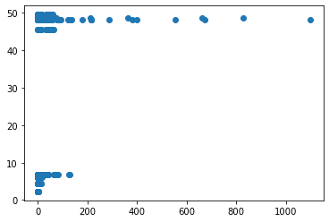

```python
plt.scatter(y_test_confirmed,pre1)
```

### 2).2ND method takes only city as feature

In this model I am using city as dependent feature and apply simple linear regression model to predict targe variable(Active cases)

```python
cv3=CVD[['City','Active_cases']]
dv3=pd.get_dummies(cv3,drop_first=True)
```

```python
X=dv3.drop(columns='Active_cases')
y=dv3[['Active_cases']]
```

### Fitting model

```python
L3=LinearRegression()
X_train_confirmed, X_test_confirmed, y_train_confirmed, y_test_confirmed = train_test_split(X, y, test_size=0.3,shuffle=False)
L3.fit(X_train_confirmed,y_train_confirmed)
pre2=L3.predict(X_test_confirmed)
```

```python
df = pd.DataFrame(data=y_test_confirmed)
df2 = pd.DataFrame(data=pre2)
df2.index = df.index

dff=pd.concat([df,df2],axis=1,ignore_index=False)
dff.columns=['Actual','Predicted']
dff
```

|  | Actual | Predicted |
| --- | --- | --- |
| 1647 | 1 | 1.875000 |
| 1648 | 0 | 13.327590 |
| 1649 | 0 | 3.137373 |
| 1650 | 0 | 1.672117 |
| 1651 | 3 | 3.000000 |
| ... | ... | ... |
| 2349 | 4 | 3.034483 |
| 2350 | 8 | 3.034483 |
| 2351 | 0 | 3.034483 |
| 2352 | 14 | 3.034483 |
| 2353 | 12 | 3.034483 |

707 rows × 2 columns

### Evaluation Metrics of model

```python
accuracy=L3.score(X_test_confirmed,y_test_confirmed)
train=L3.score(X_train_confirmed,y_train_confirmed)
results_df2 = pd.DataFrame(data=[["Linear Regression with city",*evaluate(y_test_confirmed, pre2) ,train,accuracy]],
                            columns=['Model', 'MAE', 'MSE', 'RMSE', 'R2 Square', "Train_Accuracy","Test_Accuracy"])
result_df=result_df.append(results_df2)
```

```python
results_df2
```

|  | Model | MAE | MSE | RMSE | R2 Square | Train_Accuracy | Test_Accuracy |
| --- | --- | --- | --- | --- | --- | --- | --- |
| 0 | Linear Regression with city | 1.093450e+12 | 1.056640e+26 | 1.027930e+13 | -2.152599e+22 | 0.291243 | -2.152599e+22 |

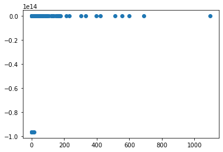

```python
plt.scatter(y_test_confirmed,pre2)
```

### 3). 3rd method take only travel history as feature

In this part i am using only travel history as a feature and develop simple linear regression model to predict target variable

```python
cv2=CVD[['Travel_history','Active_cases']]
dv2=pd.get_dummies(cv2,drop_first=True)
dv2
```

|  | Active_cases | Travel_history_China | Travel_history_Dubai | Travel_history_International_Passenger | Travel_history_Iran_Taftan | Travel_history_Jail | Travel_history_KSA | Travel_history_Local_Covid_Relative | Travel_history_Local_Social_Contact | Travel_history_Syria | Travel_history_Tableeghi_Jamaat | Travel_history_UK | Travel_history_USA | Travel_history_Unknown |
| --- | --- | --- | --- | --- | --- | --- | --- | --- | --- | --- | --- | --- | --- | --- |
| 0 | 1 | 1 | 0 | 0 | 0 | 0 | 0 | 0 | 0 | 0 | 0 | 0 | 0 | 0 |
| 1 | 2 | 0 | 0 | 0 | 1 | 0 | 0 | 0 | 0 | 0 | 0 | 0 | 0 | 0 |
| 2 | 1 | 1 | 0 | 0 | 0 | 0 | 0 | 0 | 0 | 0 | 0 | 0 | 0 | 0 |
| 3 | 1 | 0 | 0 | 0 | 1 | 0 | 0 | 0 | 0 | 0 | 0 | 0 | 0 | 0 |
| 4 | 1 | 0 | 0 | 0 | 1 | 0 | 0 | 0 | 0 | 0 | 0 | 0 | 0 | 0 |
| ... | ... | ... | ... | ... | ... | ... | ... | ... | ... | ... | ... | ... | ... | ... |
| 2349 | 4 | 0 | 0 | 0 | 0 | 0 | 0 | 0 | 1 | 0 | 0 | 0 | 0 | 0 |
| 2350 | 8 | 0 | 0 | 0 | 0 | 0 | 0 | 0 | 1 | 0 | 0 | 0 | 0 | 0 |
| 2351 | 0 | 0 | 0 | 0 | 0 | 0 | 0 | 0 | 1 | 0 | 0 | 0 | 0 | 0 |
| 2352 | 14 | 0 | 0 | 0 | 0 | 0 | 0 | 0 | 1 | 0 | 0 | 0 | 0 | 0 |
| 2353 | 12 | 0 | 0 | 0 | 0 | 0 | 0 | 0 | 1 | 0 | 0 | 0 | 0 | 0 |

2354 rows × 14 columns

### Correlation between Travel_history and Active cases through heatmap

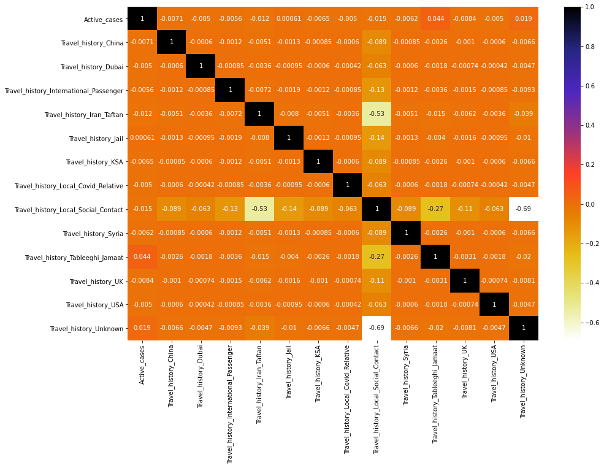

```python
Corelation = dv2.corr()
Corelation
top_fatures = Corelation.index
plt.figure(figsize = (15 ,10))
g = sns.heatmap(dv2[top_fatures].corr() , annot = True , cmap ='CMRmap_r')
```

```python
X=dv2.drop(columns='Active_cases')
y=dv2[['Active_cases']]
```

### Fit the model

```python
L2=LinearRegression()
X_train_confirmed, X_test_confirmed, y_train_confirmed, y_test_confirmed = train_test_split(X, y, test_size=0.3,shuffle=False)
L2.fit(X_train_confirmed,y_train_confirmed)
pre3=L2.predict(X_test_confirmed)
```

```python
df = pd.DataFrame(data=y_test_confirmed)
df3 = pd.DataFrame(data=pre3)
df3.index = df.index

dff=pd.concat([df,df2],axis=1,ignore_index=False)
dff.columns=['Actual','Predicted']
dff
```

|  | Actual | Predicted |
| --- | --- | --- |
| 1647 | 1 | 1.875000 |
| 1648 | 0 | 13.327590 |
| 1649 | 0 | 3.137373 |
| 1650 | 0 | 1.672117 |
| 1651 | 3 | 3.000000 |
| ... | ... | ... |
| 2349 | 4 | 3.034483 |
| 2350 | 8 | 3.034483 |
| 2351 | 0 | 3.034483 |
| 2352 | 14 | 3.034483 |
| 2353 | 12 | 3.034483 |

707 rows × 2 columns

### Evaluation Metrics of Model

```python
accuracy=L2.score(X_test_confirmed,y_test_confirmed)
train=L2.score(X_train_confirmed,y_train_confirmed)
results_df2 = pd.DataFrame(data=[["Linear Regression with Travel_History",*evaluate(y_test_confirmed, pre3) ,train,accuracy]],
                            columns=['Model', 'MAE', 'MSE', 'RMSE', 'R2 Square', "Train_Accuracy","Test_Accuracy"])
result_df=result_df.append(results_df2)
results_df2
```

|  | Model | MAE | MSE | RMSE | R2 Square | Train_Accuracy | Test_Accuracy |
| --- | --- | --- | --- | --- | --- | --- | --- |
| 0 | Linear Regression with Travel_History | 27.599303 | 4938.183054 | 70.272207 | -0.006012 | 0.00338 | -0.006012 |

```python
result_df
```

|  | Model | MAE | MSE | RMSE | R2 Square | Train_Accuracy | Test_Accuracy |
| --- | --- | --- | --- | --- | --- | --- | --- |
| 0 | Linear Regression with Province | 2.501237e+01 | 5.223878e+03 | 7.227640e+01 | 4.393540e-02 | 0.059622 | 4.393540e-02 |
| 0 | Linear Regression with city | 1.093450e+12 | 1.056640e+26 | 1.027930e+13 | -2.152599e+22 | 0.291243 | -2.152599e+22 |
| 0 | Linear Regression with Travel_History | 2.759930e+01 | 4.938183e+03 | 7.027221e+01 | -6.011990e-03 | 0.003380 | -6.011990e-03 |

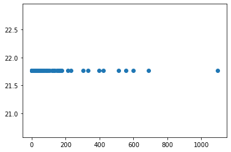

```python
plt.scatter(y_test_confirmed,pre3)
```

### 4).4th method takes only Cases as feature

```python
cv2=CVD[['Confirmed_cases','Active_cases']]
X=cv2.drop(columns='Active_cases')
y=cv2[['Active_cases']]
```

### Correlation Bewteen Confirmed and Active Cases

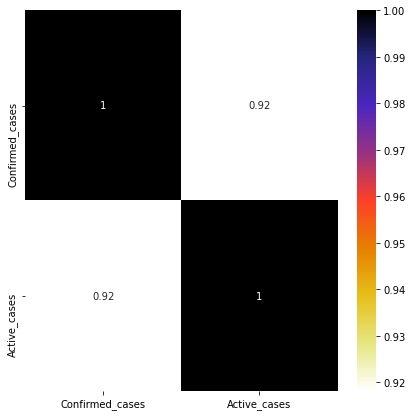

```python
Corelation = cv2.corr()
Corelation
top_fatures = Corelation.index
plt.figure(figsize = (7 , 7))
g = sns.heatmap(cv2[top_fatures].corr() , annot = True , cmap ='CMRmap_r')
```

### Fit the model

```python
L4=LinearRegression()
X_train_confirmed, X_test_confirmed, y_train_confirmed, y_test_confirmed = train_test_split(X, y, test_size=0.3,shuffle=True)

L4.fit(X_test_confirmed,y_test_confirmed)

pre4=L4.predict(X_test_confirmed)
```

```python
df = pd.DataFrame(data=y_test_confirmed)
df4 = pd.DataFrame(data=pre4)
df4.index = df.index

dff=pd.concat([df,df4],axis=1,ignore_index=False)
dff.columns=['Actual','Predicted']
dff
```

|  | Actual | Predicted |
| --- | --- | --- |
| 1067 | 1 | 2.100149 |
| 2300 | 19 | 16.703275 |
| 1416 | 17 | 15.844268 |
| 601 | 4 | 5.536179 |
| 894 | 7 | 6.395186 |
| ... | ... | ... |
| 2055 | 0 | 0.382134 |
| 1003 | 0 | 0.382134 |
| 828 | 0 | 1.241142 |
| 326 | 3 | 5.536179 |
| 479 | 1 | 2.100149 |

707 rows × 2 columns

### Evaluation Metrics

```python
accuracy=L4.score(X_test_confirmed,y_test_confirmed)
train=L4.score(X_train_confirmed,y_train_confirmed)
results_df2 = pd.DataFrame(data=[["Linear Regression with Confirmed_Cases",*evaluate(y_test_confirmed, pre4) ,train,accuracy]],
                            columns=['Model', 'MAE', 'MSE', 'RMSE', 'R2 Square', "Train_Accuracy","Test_Accuracy"])
result_df=result_df.append(results_df2)
results_df2
```

|  | Model | MAE | MSE | RMSE | R2 Square | Train_Accuracy | Test_Accuracy |
| --- | --- | --- | --- | --- | --- | --- | --- |
| 0 | Linear Regression with Confirmed_Cases | 3.957857 | 548.893924 | 23.428485 | 0.934719 | 0.688203 | 0.934719 |

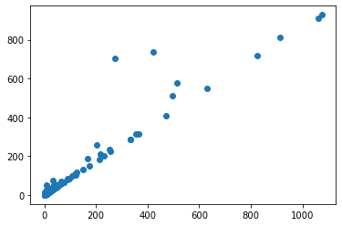

```python
plt.scatter(y_test_confirmed,pre4)
```

# *Multiple Linear Regression*

Multiple Linear regression takes multiple inputs as feature and based on this feature it will predict the target variable values.I am using all features(Day,Month,Confirmed cases,Recovered cases, Deaths cases, Province,City, Travel_history) from my dataset except target variable(Active Cases).

### *Perform dummy encoding on categorical columns*

Perform One Hot Encoding of the categorical columns so that our model will understand numerical features because machine learning models cannot take inputs as categorical or string.

```python
dv4=pd.get_dummies(CVD,drop_first=True)
dv4
```

|  | Confirmed_cases | Deaths_cases | Recovered_cases | Active_cases | Month | Day | Travel_history_China | Travel_history_Dubai | Travel_history_International_Passenger | Travel_history_Iran_Taftan | ... | City_Tando_M | City_Tank | City_Tharparkar | City_Thatta | City_Toba_Tek_Singh | City_Tor_Ghar | City_Trarkhel | City_Umerkot | City_Vehari | City_Ziarat |
| --- | --- | --- | --- | --- | --- | --- | --- | --- | --- | --- | --- | --- | --- | --- | --- | --- | --- | --- | --- | --- | --- |
| 0 | 1 | 0 | 0 | 1 | 2 | 26 | 1 | 0 | 0 | 0 | ... | 0 | 0 | 0 | 0 | 0 | 0 | 0 | 0 | 0 | 0 |
| 1 | 2 | 0 | 0 | 2 | 2 | 26 | 0 | 0 | 0 | 1 | ... | 0 | 0 | 0 | 0 | 0 | 0 | 0 | 0 | 0 | 0 |
| 2 | 1 | 0 | 0 | 1 | 2 | 29 | 1 | 0 | 0 | 0 | ... | 0 | 0 | 0 | 0 | 0 | 0 | 0 | 0 | 0 | 0 |
| 3 | 1 | 0 | 0 | 1 | 2 | 29 | 0 | 0 | 0 | 1 | ... | 0 | 0 | 0 | 0 | 0 | 0 | 0 | 0 | 0 | 0 |
| 4 | 1 | 0 | 0 | 1 | 3 | 2 | 0 | 0 | 0 | 1 | ... | 0 | 0 | 0 | 0 | 0 | 0 | 0 | 0 | 0 | 0 |
| ... | ... | ... | ... | ... | ... | ... | ... | ... | ... | ... | ... | ... | ... | ... | ... | ... | ... | ... | ... | ... | ... |
| 2349 | 5 | 1 | 0 | 4 | 5 | 27 | 0 | 0 | 0 | 0 | ... | 0 | 0 | 0 | 0 | 0 | 0 | 0 | 0 | 0 | 0 |
| 2350 | 8 | 0 | 0 | 8 | 5 | 28 | 0 | 0 | 0 | 0 | ... | 0 | 0 | 0 | 0 | 0 | 0 | 0 | 0 | 0 | 0 |
| 2351 | 7 | 1 | 6 | 0 | 5 | 29 | 0 | 0 | 0 | 0 | ... | 0 | 0 | 0 | 0 | 0 | 0 | 0 | 0 | 0 | 0 |
| 2352 | 16 | 0 | 2 | 14 | 6 | 1 | 0 | 0 | 0 | 0 | ... | 0 | 0 | 0 | 0 | 0 | 0 | 0 | 0 | 0 | 0 |
| 2353 | 13 | 1 | 0 | 12 | 6 | 2 | 0 | 0 | 0 | 0 | ... | 0 | 0 | 0 | 0 | 0 | 0 | 0 | 0 | 0 | 0 |

2354 rows × 143 columns

```python
X=dv4.drop(columns=dv4[['Active_cases']])
y=dv4[['Active_cases']]
```

### First we divide dataset into training and testing data and use the size of 70% for training samples and 30% for testing samples.

```python
X_train_confirmed, X_test_confirmed, y_train_confirmed, y_test_confirmed = train_test_split(X, y, test_size=0.3, shuffle=True, random_state=50)
```

### 1). In Multiple Linear Regression Model, I am taking all the columns except target as feature

```python
lin=LinearRegression()
lin.fit(X_train_confirmed,y_train_confirmed)
y_pred_linear=lin.predict(X_test_confirmed)



train_accuracy=lin.score(X_train_confirmed,y_train_confirmed)
test_accuracy=lin.score(X_test_confirmed,y_test_confirmed)
print("train_accuracy:",train_accuracy)
print("test accracy:",test_accuracy)
```

```
train_accuracy: 1.0
test accracy: 0.9999999999999362
```

### Evaluation Metrics of the Multiple Linear Model

```python
results_df2 = pd.DataFrame(data=[["Multiple Linear Regression",*evaluate(y_test_confirmed, y_pred_linear),train_accuracy,test_accuracy]],
                            columns=['Model', 'MAE', 'MSE', 'RMSE', 'R2 Square', "Train_Accuracy","Test_Accuracy"])
result_df=result_df.append(results_df2)
results_df2
```

|  | Model | MAE | MSE | RMSE | R2 Square | Train_Accuracy | Test_Accuracy |
| --- | --- | --- | --- | --- | --- | --- | --- |
| 0 | Multiple Linear Regression | 0.000001 | 3.485980e-10 | 0.000019 | 1.0 | 1.0 | 1.0 |

```python
RegModel.append("Multiple Linear Regression")
Train_accuracy.append(train_accuracy)
Test_Accuracy.append(test_accuracy)
```

```python
dfff = pd.DataFrame(data=y_test_confirmed)
df5 = pd.DataFrame(data=y_pred_linear)
df5.index = dfff.index

dff=pd.concat([dfff,df5],axis=1,ignore_index=False)
dff.columns=['Actual','Predicted']
dff
```

|  | Actual | Predicted |
| --- | --- | --- |
| 467 | 91 | 91.0 |
| 1674 | 2 | 2.0 |
| 917 | 5 | 5.0 |
| 1158 | 3 | 3.0 |
| 499 | 4 | 4.0 |
| ... | ... | ... |
| 2179 | 1 | 1.0 |
| 1542 | 1 | 1.0 |
| 393 | 4 | 4.0 |
| 1014 | 1 | 1.0 |
| 2060 | 40 | 40.0 |

707 rows × 2 columns

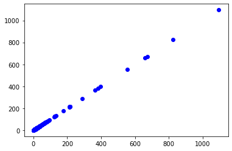

```python
plt.scatter(y_test_confirmed,y_pred_linear,color='blue')
```

## *Support Vector Regression*

Feature scaling transforms your data such that the resulting distribution has a mean of 0 and a standard deviation of 1.As we know SVR requires standarized data so i am performing feature scaling.

```python
st_x=StandardScaler()
st_y=StandardScaler()
X1=st_x.fit_transform(X)
Y1=st_y.fit_transform(y)
```

```python
X_train, X_test, y_train, y_test = train_test_split(X1, Y1, test_size=0.3,shuffle=True)
```

```python
resg=SVR(kernel='rbf',degree=5)
resg.fit(X_train,y_train)
y_pred_svm=resg.predict(X_test)
```

```python
dfff = pd.DataFrame(data=y_test)
df6 = pd.DataFrame(data=y_pred_svm)
df6.index = dfff.index

dff=pd.concat([dfff,df6],axis=1,ignore_index=False)
dff.columns=['Actual','Predicted']
dff
```

|  | Actual | Predicted |
| --- | --- | --- |
| 0 | -0.004379 | -0.074343 |
| 1 | -0.255200 | -0.187991 |
| 2 | -0.205036 | -0.177817 |
| 3 | -0.129790 | -0.107560 |
| 4 | -0.255200 | -0.155567 |
| ... | ... | ... |
| 702 | -0.205036 | -0.154648 |
| 703 | 13.489797 | 2.979443 |
| 704 | -0.242659 | -0.189366 |
| 705 | -0.255200 | -0.188003 |
| 706 | -0.205036 | -0.207134 |

707 rows × 2 columns

### Train and test accuracy

```python
train_accuracy=resg.score(X_train,y_train)
test_accuracy=resg.score(X_test,y_test)
```

### *Evaluation Metrics of Support Vector Regression*

```python
results_df2 = pd.DataFrame(data=[["Support Vector Regression Regression",*evaluate(y_test, y_pred_svm),train_accuracy,test_accuracy]],
                            columns=['Model', 'MAE', 'MSE', 'RMSE', 'R2 Square', "Train_Accuracy","Test_Accuracy"])
result_df=result_df.append(results_df2)
results_df2
```

|  | Model | MAE | MSE | RMSE | R2 Square | Train_Accuracy | Test_Accuracy |
| --- | --- | --- | --- | --- | --- | --- | --- |
| 0 | Support Vector Regression Regression | 0.140792 | 0.356457 | 0.59704 | 0.651299 | 0.859803 | 0.651299 |

```python
RegModel.append("Support vector Regression")
Train_accuracy.append(train_accuracy)
Test_Accuracy.append(test_accuracy)
```

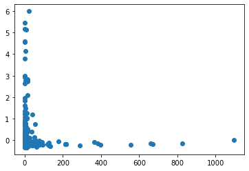

```python
plt.scatter(y_test_confirmed,y_pred_svm)
```

## *Ridge Regression*

Ridge Regression is a technique for analyzing multiple regression data that suffer from multicollinearity. When multicollinearity occurs, least squares estimates are unbiased, but their variances are large so they may be far from the true value. By adding a degree of bias to the regression estimates, ridge regression reduces the standard errors.

### Hyperparameter optimization using GridSearchCV

```python
alpha_values = {'alpha':[0.001, 0.01,0.02,0.03,0.04, 0.05, 0.06, 0.08, 1, 2, 3, 5, 8, 10, 20, 50, 100]}
ridge= GridSearchCV(Ridge(), alpha_values, scoring='neg_mean_squared_error', cv=10 )
best=ridge.fit(X,y).best_params_
print('The best value of alpha is:',best)
```

```
The best value of alpha is: {'alpha': 0.001}
```

As Gridsearchcv gives us the best alpha value 0.001 so we use in our model

```python
ridge=Ridge(alpha=0.001)
ridge.fit(X_train_confirmed,y_train_confirmed)
y_pred_ridge=ridge.predict(X_test_confirmed)
```

```python
dfff = pd.DataFrame(data=y_test_confirmed)
df7 = pd.DataFrame(data=y_pred_ridge)
df7.index = dfff.index

dff=pd.concat([dfff,df7],axis=1,ignore_index=False)
dff.columns=['Actual','Predicted']
dff
```

|  | Actual | Predicted |
| --- | --- | --- |
| 467 | 91 | 90.999999 |
| 1674 | 2 | 2.000000 |
| 917 | 5 | 5.000000 |
| 1158 | 3 | 3.000000 |
| 499 | 4 | 4.000000 |
| ... | ... | ... |
| 2179 | 1 | 1.000000 |
| 1542 | 1 | 1.000000 |
| 393 | 4 | 4.000000 |
| 1014 | 1 | 1.000000 |
| 2060 | 40 | 40.000000 |

707 rows × 2 columns

## Train and test accuracy

```python
train_accuracy=ridge.score(X_train_confirmed,y_train_confirmed)
test_accuracy=ridge.score(X_test_confirmed,y_test_confirmed)
```

### *Evaluation Metrics of the Ridge Model*

```python
results_df2 = pd.DataFrame(data=[["Ridge model ",*evaluate(y_test_confirmed, y_pred_ridge),train_accuracy,test_accuracy]],
                            columns=['Model', 'MAE', 'MSE', 'RMSE', 'R2 Square', "Train_Accuracy","Test_Accuracy"])
result_df=result_df.append(results_df2)
```

```python
results_df2
```

|  | Model | MAE | MSE | RMSE | R2 Square | Train_Accuracy | Test_Accuracy |
| --- | --- | --- | --- | --- | --- | --- | --- |
| 0 | Ridge model | 1.667862e-07 | 2.156288e-13 | 4.643585e-07 | 1.0 | 1.0 | 1.0 |

```python
RegModel.append("Ridge Regression")
Train_accuracy.append(train_accuracy)
Test_Accuracy.append(test_accuracy)
```

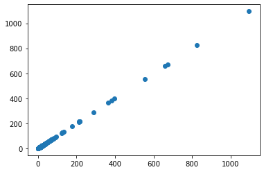

```python
plt.scatter(y_test_confirmed,y_pred_ridge)
```

## *Lasso Regression*

Lasso regression is what is called the Penalized regression method, often used in machine learning to select the subset of variables. It is a supervised machine learning method. Specifically, LASSO is a Shrinkage and Variable Selection method for linear regression models.

```python
alpha_values = {'alpha':[0.001, 0.01,0.02,0.03,0.04, 0.05, 0.06, 0.08, 1, 2, 3, 5, 8, 10, 20, 50, 100]}
lasso= GridSearchCV(Lasso(), alpha_values, scoring='neg_mean_squared_error', cv=10 )
print('The best value of alpha is:',lasso.fit(X,y).best_params_)
```

```
The best value of alpha is: {'alpha': 0.001}
```

```python
lasso=Lasso(alpha=0.001)
```

### Fit the Lasso Regression Model

```python
lasso.fit(X_train_confirmed,y_train_confirmed)
y_pred_lasso=lasso.predict(X_test_confirmed)
```

```python
y_pred_lasso=pd.DataFrame(y_pred_lasso)
```

### Train and terst accuracy

```python
test_accuracy=lasso.score(X_test_confirmed,y_test_confirmed)
train_acccuracy=lasso.score(X_train_confirmed,y_train_confirmed)
print("train_accuracy:",train_accuracy)
print("test accracy:",test_accuracy)
```

```
train_accuracy: 1.0
test accracy: 0.9999999996443303
```

```python
dfff = pd.DataFrame(data=y_test_confirmed)
df8 = pd.DataFrame(data=y_pred_lasso)
df8.index = dfff.index

dff=pd.concat([dfff,df8],axis=1,ignore_index=False)
dff.columns=['Actual','Predicted']
dff
```

|  | Actual | Predicted |
| --- | --- | --- |
| 467 | 91 | 91.000776 |
| 1674 | 2 | 1.999643 |
| 917 | 5 | 4.999657 |
| 1158 | 3 | 2.999648 |
| 499 | 4 | 3.999653 |
| ... | ... | ... |
| 2179 | 1 | 0.999638 |
| 1542 | 1 | 0.999638 |
| 393 | 4 | 3.999653 |
| 1014 | 1 | 0.999638 |
| 2060 | 40 | 39.999761 |

707 rows × 2 columns

### Evaluation Metrics of the Lasso Model

```python
results_df2 = pd.DataFrame(data=[["LASSO model ",*evaluate(y_test_confirmed, y_pred_lasso),test_accuracy,train_accuracy]],
                            columns=['Model', 'MAE', 'MSE', 'RMSE', 'R2 Square', "Train_Accuracy","Test_Accuracy"])
result_df=result_df.append(results_df2)
results_df2
```

|  | Model | MAE | MSE | RMSE | R2 Square | Train_Accuracy | Test_Accuracy |
| --- | --- | --- | --- | --- | --- | --- | --- |
| 0 | LASSO model | 0.000575 | 0.000002 | 0.001394 | 1.0 | 1.0 | 1.0 |

```python
RegModel.append("Lasso Regression")
Train_accuracy.append(train_accuracy)
Test_Accuracy.append(test_accuracy)
```

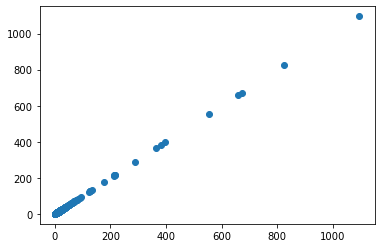

```python
plt.scatter(y_test_confirmed,y_pred_lasso)
```

## *Random Forest Regression*

A random forest is a meta estimator that fits a number of classifying decision trees on various sub-samples of the dataset and uses averaging to improve the predictive accuracy and control over-fitting. The sub-sample size is controlled with the max_samples parameter if bootstrap=True (default), otherwise the whole dataset is used to build each tree.

### Hyperparameter tunning for random forest regression

```python
rf=RandomForestRegressor()

 #Number of trees in random forest
n_estimators = [int(x) for x in np.linspace(start = 100, stop = 1200, num = 12)]
#Number of features to consider at every split
max_features = ['auto', 'sqrt']
# Maximum number of levels in tree
max_depth = [int(x) for x in np.linspace(5, 30, num = 6)]
max_depth.append(None)
#Minimum number of samples required to split a node
min_samples_split = [2, 5, 10, 15, 100]
#Minimum number of samples required at each leaf node
min_samples_leaf = [1, 2, 5, 10]
```

```python
random_grid = {'n_estimators': n_estimators,
               'max_features': max_features,
               'max_depth': max_depth,
               'min_samples_split': min_samples_split,
               'min_samples_leaf': min_samples_leaf}

print(random_grid)
```

```
{'n_estimators': [100, 200, 300, 400, 500, 600, 700, 800, 900, 1000, 1100, 1200], 'max_features': ['auto', 'sqrt'], 'max_depth': [5, 10, 15, 20, 25, 30, None], 'min_samples_split': [2, 5, 10, 15, 100], 'min_samples_leaf': [1, 2, 5, 10]}
```

```python
rf_random = RandomizedSearchCV(estimator = rf, param_distributions = random_grid,scoring='neg_mean_squared_error', n_iter = 10, cv = 5, verbose=2, random_state=42,n_jobs=5)
```

```python
rf_random.fit(X_train_confirmed,y_train_confirmed)
```

```
Fitting 5 folds for each of 10 candidates, totalling 50 fits
```

```
[Parallel(n_jobs=5)]: Using backend LokyBackend with 5 concurrent workers.
[Parallel(n_jobs=5)]: Done  31 tasks      | elapsed:  1.7min
[Parallel(n_jobs=5)]: Done  50 out of  50 | elapsed:  2.2min finished
```

```
RandomizedSearchCV(cv=5, estimator=RandomForestRegressor(), n_jobs=5,
                   param_distributions={'max_depth': [5, 10, 15, 20, 25, 30,
                                                      None],
                                        'max_features': ['auto', 'sqrt'],
                                        'min_samples_leaf': [1, 2, 5, 10],
                                        'min_samples_split': [2, 5, 10, 15,
                                                              100],
                                        'n_estimators': [100, 200, 300, 400,
                                                         500, 600, 700, 800,
                                                         900, 1000, 1100,
                                                         1200]},
                   random_state=42, scoring='neg_mean_squared_error',
                   verbose=2)
```

```python
best_rf=rf_random.estimator
best_rf
```

```
RandomForestRegressor()
```

```python
best_rf.fit(X_train_confirmed,y_train_confirmed)

y_pred_forest=best_rf.predict(X_test_confirmed)
```

```python
dfff = pd.DataFrame(data=y_test_confirmed)
df9 = pd.DataFrame(data=y_pred_forest)
df9.index = dfff.index

dff=pd.concat([dfff,df9],axis=1,ignore_index=False)
dff.columns=['Actual','Predicted']
dff
```

|  | Actual | Predicted |
| --- | --- | --- |
| 467 | 91 | 89.68 |
| 1674 | 2 | 2.00 |
| 917 | 5 | 5.00 |
| 1158 | 3 | 3.00 |
| 499 | 4 | 4.00 |
| ... | ... | ... |
| 2179 | 1 | 1.00 |
| 1542 | 1 | 1.00 |
| 393 | 4 | 4.00 |
| 1014 | 1 | 1.00 |
| 2060 | 40 | 36.21 |

707 rows × 2 columns

## Train and Test Accuracy

```python
test_accuracy=best_rf.score(X_test_confirmed,y_test_confirmed)
train_acccuracy=best_rf.score(X_train_confirmed,y_train_confirmed)
```

### Evaluation Metrics of the Random Forest model

```python
results_df2 = pd.DataFrame(data=[["Random Forest model ",*evaluate(y_test_confirmed, y_pred_forest ),train_accuracy,test_accuracy]],
                            columns=['Model', 'MAE', 'MSE', 'RMSE', 'R2 Square', "Train_Accuracy","Test_Accuracy"])
result_df=result_df.append(results_df2)
results_df2
```

|  | Model | MAE | MSE | RMSE | R2 Square | Train_Accuracy | Test_Accuracy |
| --- | --- | --- | --- | --- | --- | --- | --- |
| 0 | Random Forest model | 3.851513 | 1097.14697 | 33.123209 | 0.799202 | 1.0 | 0.799202 |

```python
RegModel.append("Random Forest  Regression")
Train_accuracy.append(train_accuracy)
Test_Accuracy.append(test_accuracy)
```

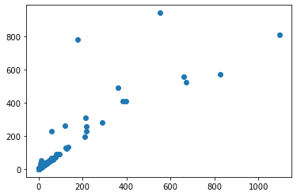

```python
plt.scatter(y_test_confirmed,y_pred_forest)
```

## *Decision Tree Regression*

Decision tree builds regression models in the form of a tree structure. It breaks down a dataset into smaller and smaller subsets while at the same time an associated decision tree is incrementally developed. The final result is a tree with decision nodes and leaf nodes.

### Decision Tree Hyperparameter Optimization

```python
parameters = {'max_depth' : (3,5,7,9,10,15,20,25)
              , 'criterion' : ('mse', 'mae')
              , 'max_features' : ('auto', 'sqrt', 'log2')
              , 'min_samples_split' : (2,4,6,8,10)
             }
```

```python
reg  = RandomizedSearchCV(DecisionTreeRegressor(), param_distributions = parameters,cv=10, verbose = True,random_state=51)
```

```python
reg.fit(X_train_confirmed,y_train_confirmed)
```

```
Fitting 10 folds for each of 10 candidates, totalling 100 fits
```

```
[Parallel(n_jobs=1)]: Using backend SequentialBackend with 1 concurrent workers.
[Parallel(n_jobs=1)]: Done 100 out of 100 | elapsed:   13.9s finished
```

```
RandomizedSearchCV(cv=10, estimator=DecisionTreeRegressor(),
                   param_distributions={'criterion': ('mse', 'mae'),
                                        'max_depth': (3, 5, 7, 9, 10, 15, 20,
                                                      25),
                                        'max_features': ('auto', 'sqrt',
                                                         'log2'),
                                        'min_samples_split': (2, 4, 6, 8, 10)},
                   random_state=51, verbose=True)
```

```python
best=reg.estimator
best
```

```
DecisionTreeRegressor()
```

```python
best.fit(X_train_confirmed,y_train_confirmed)
```

```
DecisionTreeRegressor()
```

```python
pred_dt=best.predict(X_test_confirmed)
```

```python
dfff = pd.DataFrame(data=y_test_confirmed)
df10 = pd.DataFrame(data=pred_dt)
df10.index = dfff.index

dff=pd.concat([dfff,df10],axis=1,ignore_index=False)
dff.columns=['Actual','Predicted']
dff
```

|  | Actual | Predicted |
| --- | --- | --- |
| 467 | 91 | 83.0 |
| 1674 | 2 | 2.0 |
| 917 | 5 | 5.0 |
| 1158 | 3 | 3.0 |
| 499 | 4 | 4.0 |
| ... | ... | ... |
| 2179 | 1 | 1.0 |
| 1542 | 1 | 1.0 |
| 393 | 4 | 4.0 |
| 1014 | 1 | 1.0 |
| 2060 | 40 | 30.0 |

707 rows × 2 columns

### Train and test accuracy

```python
test_accuracy=best.score(X_test_confirmed,y_test_confirmed)
train_acccuracy=best.score(X_train_confirmed,y_train_confirmed)
```

### Evaluation Metrics of DeCision TREE Regression Model

```python
results_df2 = pd.DataFrame(data=[["Decision tree model ",*evaluate(y_test_confirmed, pred_dt ),train_accuracy,test_accuracy]],
                            columns=['Model', 'MAE', 'MSE', 'RMSE', 'R2 Square', "Train_Accuracy","Test_Accuracy"])
result_df=result_df.append(results_df2)
results_df2
```

|  | Model | MAE | MSE | RMSE | R2 Square | Train_Accuracy | Test_Accuracy |
| --- | --- | --- | --- | --- | --- | --- | --- |
| 0 | Decision tree model | 3.735502 | 1085.39604 | 32.945349 | 0.801353 | 1.0 | 0.801353 |

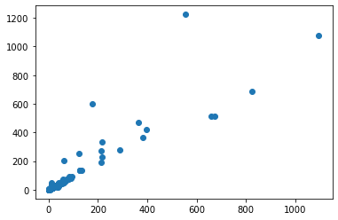

```python
plt.scatter(y_test_confirmed,pred_dt)
```

## *Xgboost Regression*

### Fitting model

```python
reg = XGBRegressor()
reg.fit(X_train_confirmed, y_train_confirmed)
XGB_pred = reg.predict(X_test_confirmed)
```

```python
test_accuracy=reg.score(X_test_confirmed,y_test_confirmed)
train_acccuracy=reg.score(X_train_confirmed,y_train_confirmed)
```

### Evaluation Metrics of XGBoost Regression Model

```python
print("train accuracy:",train_accuracy)
print("test accuracy:",test_accuracy)
```

```
train accuracy: 1.0
test accuracy: 0.6962447084878395
```

### Hyperparameter tunning Using RandomizedSearchCV

```python
regressor=XGBRegressor()
```

```python
n_estimators = [100, 500, 900, 1100, 1500]
max_depth = [2, 3, 5, 10, 15]
booster=['gbtree','gblinear']
learning_rate=[0.05,0.1,0.15,0.20]
min_child_weight=[1,2,3,4]
base_score=[0.25,0.5,0.75,1]

hyperparameter_grid = {
    'n_estimators': n_estimators,
    'max_depth':max_depth,
    'learning_rate':learning_rate,
    'min_child_weight':min_child_weight,
    'booster':booster,
    'base_score':base_score
    }
```

```python
random_cv = RandomizedSearchCV(estimator=regressor,
            param_distributions=hyperparameter_grid,
            cv=5, n_iter=50,
            scoring = 'neg_mean_absolute_error',n_jobs = 10,
            verbose = 5,
            return_train_score = True,
            random_state=42)
```

```python
random_cv.fit(X_train_confirmed,y_train_confirmed)
```

```
Fitting 5 folds for each of 50 candidates, totalling 250 fits
```

```
[Parallel(n_jobs=10)]: Using backend LokyBackend with 10 concurrent workers.
[Parallel(n_jobs=10)]: Done  52 tasks      | elapsed:  4.1min
[Parallel(n_jobs=10)]: Done 142 tasks      | elapsed:  6.9min
[Parallel(n_jobs=10)]: Done 250 out of 250 | elapsed: 10.3min finished
```

[output not shown]

```
RandomizedSearchCV(cv=5,
                   estimator=XGBRegressor(base_score=None, booster=None,
                                          colsample_bylevel=None,
                                          colsample_bynode=None,
                                          colsample_bytree=None, gamma=None,
                                          gpu_id=None, importance_type='gain',
                                          interaction_constraints=None,
                                          learning_rate=None,
                                          max_delta_step=None, max_depth=None,
                                          min_child_weight=None, missing=nan,
                                          monotone_constraints=None,
                                          n_estimators=100, n...
                                          validate_parameters=None,
                                          verbosity=None),
                   n_iter=50, n_jobs=10,
                   param_distributions={'base_score': [0.25, 0.5, 0.75, 1],
                                        'booster': ['gbtree', 'gblinear'],
                                        'learning_rate': [0.05, 0.1, 0.15, 0.2],
                                        'max_depth': [2, 3, 5, 10, 15],
                                        'min_child_weight': [1, 2, 3, 4],
                                        'n_estimators': [100, 500, 900, 1100,
                                                         1500]},
                   random_state=42, return_train_score=True,
                   scoring='neg_mean_absolute_error', verbose=5)
```

```python
best=random_cv.estimator
```

```python
best
```

```
XGBRegressor(base_score=None, booster=None, colsample_bylevel=None,
             colsample_bynode=None, colsample_bytree=None, gamma=None,
             gpu_id=None, importance_type='gain', interaction_constraints=None,
             learning_rate=None, max_delta_step=None, max_depth=None,
             min_child_weight=None, missing=nan, monotone_constraints=None,
             n_estimators=100, n_jobs=None, num_parallel_tree=None,
             random_state=None, reg_alpha=None, reg_lambda=None,
             scale_pos_weight=None, subsample=None, tree_method=None,
             validate_parameters=None, verbosity=None)
```

```python
best.fit(X_train_confirmed,y_train_confirmed)

XGB_pred=best.predict(X_test_confirmed)
```

```python
dfff = pd.DataFrame(data=y_test_confirmed)
df11 = pd.DataFrame(data=XGB_pred)
df11.index = dfff.index

dff=pd.concat([dfff,df11],axis=1,ignore_index=False)
dff.columns=['Actual','Predicted']
dff
```

|  | Actual | Predicted |
| --- | --- | --- |
| 467 | 91 | 91.851295 |
| 1674 | 2 | 1.978243 |
| 917 | 5 | 5.023557 |
| 1158 | 3 | 2.991876 |
| 499 | 4 | 3.963663 |
| ... | ... | ... |
| 2179 | 1 | 0.999480 |
| 1542 | 1 | 1.007973 |
| 393 | 4 | 3.968160 |
| 1014 | 1 | 0.995941 |
| 2060 | 40 | 36.150059 |

707 rows × 2 columns

### Train and test accuracy

```python
test_accuracy=best.score(X_test_confirmed,y_test_confirmed)
train_acccuracy=best.score(X_train_confirmed,y_train_confirmed)
```

### Evaluation metrics of XGB regressor

```python
results_df2 = pd.DataFrame(data=[["XGBRegressor model ",*evaluate(y_test_confirmed, XGB_pred),train_accuracy,test_accuracy]],
                            columns=['Model', 'MAE', 'MSE', 'RMSE', 'R2 Square', "Train_Accuracy","Test_Accuracy"])
result_df=result_df.append(results_df2)
results_df2
```

|  | Model | MAE | MSE | RMSE | R2 Square | Train_Accuracy | Test_Accuracy |
| --- | --- | --- | --- | --- | --- | --- | --- |
| 0 | XGBRegressor model | 3.963043 | 1659.700296 | 40.739419 | 0.696245 | 1.0 | 0.696245 |

```python
RegModel.append("XGB Regression")
Train_accuracy.append(train_accuracy)
Test_Accuracy.append(test_accuracy)
```

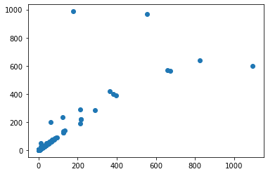

```python
plt.scatter(y_test_confirmed,XGB_pred)
```

## *All Models Evaluation Metrics*

## Accuracy of each model

```python
Regmodel=pd.DataFrame(RegModel)
Test_accuracy=pd.DataFrame(Test_Accuracy)
Train_Accuracy=pd.DataFrame(Train_accuracy)
featurescores=pd.concat([Regmodel,Test_accuracy,Train_Accuracy],axis=1)
featurescores.columns=['Model_Nmae','Test_Accuracy','Train_Accuracy']
featurescores
```

|  | Model_Nmae | Test_Accuracy | Train_Accuracy |
| --- | --- | --- | --- |
| 0 | Multiple Linear Regression | 1.000000 | 1.000000 |
| 1 | Support vector Regression | 0.651299 | 0.859803 |
| 2 | Ridge Regression | 1.000000 | 1.000000 |
| 3 | Lasso Regression | 1.000000 | 1.000000 |
| 4 | Random Forest Regression | 0.799202 | 1.000000 |
| 5 | XGB Regression | 0.696245 | 1.000000 |

```python
Test_Accuracy
```

```
[0.9999999999999362,
 0.651299265003467,
 1.0,
 0.9999999996443303,
 0.7992021820465509,
 0.6962447084878395]
```

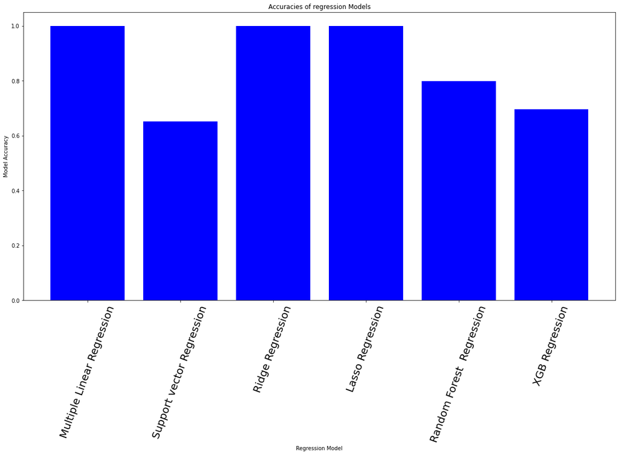

```python
Index = [1,2,3,4,5,6]
plt.figure(figsize=(20,10))
plt.bar(Index,Test_Accuracy,color='b')
plt.xticks(Index, RegModel,rotation=70,fontsize=20)
plt.ylabel('Model Accuracy')
plt.xlabel('Regression Model')
plt.title('Accuracies of regression Models')
```

# *Feature Selection Techniques*

Feature Selection is the process where you automatically or manually select those features which contribute most to your prediction variable or output in which you are interested in. Having irrelevant features in your data can decrease the accuracy of the models and make your model learn based on irrelevant features.

### Feature selection using ExtaTree Regressor

You can get the feature importance of each feature of your dataset by using the feature importance property of the model.

Feature importance gives you a score for each feature of your data, the higher the score more important or relevant is the feature towards your output variable.

Feature importance is an inbuilt class that comes with Tree Based Regressor, we will be using Extra Tree Regressor for extracting the top 10 features for the dataset.

```python
X=dv4.drop(columns=['Active_cases'])
y=dv4['Active_cases']
```

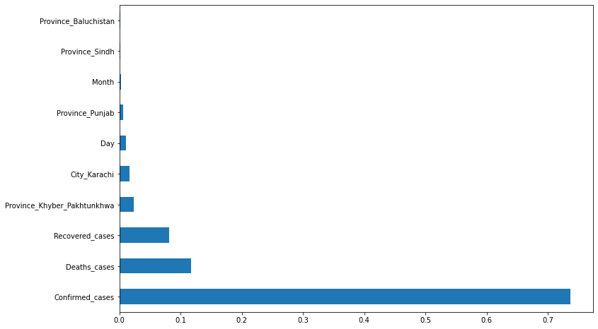

```python
from sklearn.ensemble import ExtraTreesRegressor
selection = ExtraTreesRegressor(n_estimators=10,criterion='mse')
selection.fit(X, y)
plt.figure(figsize = (12,8))
feat_importances = pd.Series(selection.feature_importances_, index=X.columns)
w=feat_importances.nlargest(10)
w.plot(kind='barh')
plt.show()
```

### Feature Selection using Recursive Feature Elimination

Recursive feature elimination (RFE) is a feature selection method that fits a model and removes the weakest feature (or features) until the specified number of features is reached.

```python
feature_names = X.columns
coef = lin.coef_

# sort them out in descending order
indices = np.argsort(np.absolute(coef))
indices = np.flip(indices, axis=0)
```

```python
estimator =LinearRegression()
selector = RFE(estimator, n_features_to_select=10, step=1)
selector = selector.fit(X, y)
```

```python
feature_importance = list(zip(feature_names, selector.support_))
new_features = []
for key,value in enumerate(feature_importance):
    if(value[1]) == True:
        new_features.append(value[0])

print(new_features)
```

```
['Confirmed_cases', 'Deaths_cases', 'Recovered_cases', 'Province_Baluchistan', 'Province_Federal_Administration_Tribal_Area', 'Province_Gilgit_Baltistan', 'Province_Islamabad_Capital_Territory', 'Province_Khyber_Pakhtunkhwa', 'Province_Sindh', 'City_Multan']
```

## Multiple linear Regression model after selecting best feature

```python
X_new = dv4[new_features]
y=dv4[['Active_cases']]

X_train_1, X_test_1, y_train_1, y_test_1= train_test_split(X_new, y, test_size=0.3, shuffle=True)
```

```python
resg=LinearRegression()
resg.fit(X_train_1,y_train_1)
```

```
LinearRegression()
```

```python
y_pred=resg.predict(X_test_1)
print("After Feature selection test accuracy:",resg.score(X_test_1, y_test_1))
print("After Feature selection train:",resg.score(X_train_1,y_train_1))
```

```
After Feature selection test accuracy: 1.0
After Feature selection train: 1.0
```

```python
y_pred
```

[output not shown]

[output cut: 652 more lines]

```
       [2.00000000e+00],
       [8.00000000e+00],
       [1.00000000e+00],
       [4.00000000e+00],
       [1.28250705e-14],
       [6.00000000e+00],
       [2.50000000e+01],
       [1.28250705e-14],
       [9.00000000e+00],
       [4.00000000e+00],
       [2.00000000e+00],
       [1.77635684e-14],
       [8.00000000e+00],
       [1.00000000e+00],
       [6.00000000e+00]])
```

```python
y_test_1
```

|  | Active_cases |
| --- | --- |
| 1667 | 0 |
| 251 | 0 |
| 429 | 12 |
| 147 | 6 |
| 387 | 2 |
| ... | ... |
| 185 | 2 |
| 1279 | 0 |
| 265 | 8 |
| 911 | 1 |
| 1500 | 6 |

707 rows × 1 columns

### Random Forest Regression with best selected features

```python
estimator =RandomForestRegressor()
selector = RFE(estimator, n_features_to_select=10, step=1)
selector = selector.fit(X, y)
```

```python
X=X_new = dv4[new_features]
y=dv4[['Active_cases']]
X_train_1, X_test_1, y_train_1, y_test_1= train_test_split(X_new, y, test_size=0.3, shuffle=True)
model = RandomForestRegressor()
model.fit(X_train_1,y_train_1)
y_predict = model.predict(X_test_1)
```

```python
print("After feature selection train accutacy:",model.score(X_train_1,y_train_1) )
print("After Feature selection test accuracy :",model.score(X_test_1, y_test_1))
```

```
After feature selection train accutacy: 0.9891769908549738
After Feature selection test accuracy : 0.8829167268701461
```

```python
y_test_1
```

|  | Active_cases |
| --- | --- |
| 182 | 4 |
| 1222 | 3 |
| 1959 | 0 |
| 757 | 1 |
| 899 | 17 |
| ... | ... |
| 464 | 2 |
| 636 | 8 |
| 81 | 1 |
| 1443 | 0 |
| 985 | 2 |

707 rows × 1 columns

```python
y_predict
```

[output not shown]

[output cut: 87 more lines]

```
       1.0000e+00, 6.0000e+00, 1.0000e+01, 9.3530e+01, 1.5590e+01,
       5.0000e+00, 0.0000e+00, 2.0000e+00, 3.0000e+00, 2.0000e+00,
       5.0700e+00, 0.0000e+00, 4.0000e+00, 1.6970e+01, 0.0000e+00,
       0.0000e+00, 4.9900e+00, 1.0000e+00, 1.0000e+00, 0.0000e+00,
       0.0000e+00, 1.0000e+00, 5.0000e+00, 4.8080e+01, 1.0000e+00,
       1.0990e+01, 3.0000e+00, 0.0000e+00, 1.1990e+01, 0.0000e+00,
       0.0000e+00, 1.0000e+00, 1.6000e+01, 1.0000e+00, 3.5700e+00,
       6.5170e+01, 5.0000e+00, 9.9700e+00, 0.0000e+00, 0.0000e+00,
       0.0000e+00, 1.9800e+00, 0.0000e+00, 0.0000e+00, 7.0000e+00,
       5.0000e+00, 6.5640e+01, 1.8960e+01, 0.0000e+00, 0.0000e+00,
       3.0000e+00, 9.3100e+01, 1.9800e+00, 7.5700e+00, 2.0000e+00,
       1.0000e+00, 1.0000e+00, 7.0000e+00, 1.7920e+01, 1.0000e+00,
       1.0000e+00, 1.6990e+01, 1.1640e+01, 6.9600e+01, 4.0000e+00,
       2.2670e+01, 2.7560e+01, 2.0000e+00, 8.0000e+00, 1.0000e+00,
       0.0000e+00, 2.0000e+00])
```

### Decision tree model with best selected features

```python
estimator =DecisionTreeRegressor()
selector = RFE(estimator, n_features_to_select=10, step=1)
selector = selector.fit(X, y)

feature_importance = list(zip(feature_names, selector.support_))
new_features = []
for key,value in enumerate(feature_importance):
    if(value[1]) == True:
        new_features.append(value[0])

print(new_features)
```

```
['Confirmed_cases', 'Deaths_cases', 'Recovered_cases', 'Month', 'Day', 'Travel_history_China', 'Travel_history_Dubai', 'Travel_history_International_Passenger', 'Travel_history_Iran_Taftan', 'Travel_history_Jail']
```

```python
X=X_new = dv4[new_features]
y=dv4[['Active_cases']]
X_train_1, X_test_1, y_train_1, y_test_1= train_test_split(X, y, test_size=0.3, shuffle=True)
dt2=DecisionTreeRegressor()
dt2.fit(X_train_1,y_train_1)
y_pred_forest=dt2.predict(X_test_1)
print("After feature selection accuracy trai  accuracy :",dt2.score(X_train_1,y_train_1))
print("After feature selection accurac test accuracy :",dt2.score(X_test_1, y_test_1))
```

```
After feature selection accuracy trai  accuracy : 1.0
After feature selection accurac test accuracy : 0.8935251186311141
```

```python
y_test_1
```

|  | Active_cases |
| --- | --- |
| 846 | 4 |
| 317 | 1 |
| 487 | 75 |
| 1790 | 1 |
| 1431 | 0 |
| ... | ... |
| 1953 | 4 |
| 1647 | 1 |
| 1677 | 0 |
| 1996 | 0 |
| 1784 | 0 |

707 rows × 1 columns

```python
y_pred_forest
```

[output not shown]

[output cut: 10 more lines]

```
         0.,   0.,   1.,   6.,   0.,   8.,  21.,  10.,  13.,  52.,   1.,
         0.,   3.,   1.,   0.,   3.,  16.,   1., 254.,   6.,  29.,   6.,
         2.,   1.,   0.,   4.,   0.,  11.,   7.,   3.,   6.,   1.,   1.,
         0.,   1.,   0.,   8.,   7.,   6.,  13.,   3.,   2.,  24.,   2.,
       826.,  23.,   0.,   2.,   3.,   0.,   0.,   0.,   1.,   4.,   6.,
         3.,   6.,   0.,  29.,   2.,   1.,   1.,  69.,   0.,  10.,   1.,
       140.,   0.,   1.,   6.,   2.,  11.,  13.,   0.,   3.,  10.,   1.,
         0.,   5.,   1.,  49., 178.,   0.,  21.,  31.,   1.,   0.,   1.,
         2.,   0.,   0.,  12.,   8.,   4.,   1.,   1.,   3., 382.,   3.,
         6.,   0.,   0.,   1.,   0.,   0.,   0.,  23.,  47.,   2.,   0.,
         1.,   3.,   0.,   3.,  12.,   1., 176.,   3.,  17., 126.,   2.,
        21.,   5.,   2.,   6.,   6.,  34.,  13.,   1.,   3., 826.,   0.,
         0.,  41.,  13.,   8.,  17.,   1.,  28.,   3.,   2.,   0.,   8.,
         0.,   1.,   3.,   2.,  16.,   3.,   3.,   2.,   1.,   4.,   1.,
         0.,   1.,   0.])
```

# *CLASSIFICATION MODELS*

Above we apply regression models to predict our target variable (Active cases) Now we are applying classification models to predict our target variable(Province) which is a categorical column. I am applying

- Random forest classifier
- XGB classifier
- Naive Bayes
- Support vector classifier
- Logistic Regression

```python
Accuracy=[]
ClassificationModels=[]
```

```python
CVD
```

|  | Confirmed_cases | Deaths_cases | Recovered_cases | Travel_history | Province | City | Active_cases | Month | Day |
| --- | --- | --- | --- | --- | --- | --- | --- | --- | --- |
| 0 | 1 | 0 | 0 | China | Islamabad_Capital_Territory | Islamabad | 1 | 2 | 26 |
| 1 | 2 | 0 | 0 | Iran_Taftan | Sindh | Karachi | 2 | 2 | 26 |
| 2 | 1 | 0 | 0 | China | Islamabad_Capital_Territory | Islamabad | 1 | 2 | 29 |
| 3 | 1 | 0 | 0 | Iran_Taftan | Sindh | Karachi | 1 | 2 | 29 |
| 4 | 1 | 0 | 0 | Iran_Taftan | Gilgit_Baltistan | Gilgit | 1 | 3 | 2 |
| ... | ... | ... | ... | ... | ... | ... | ... | ... | ... |
| 2349 | 5 | 1 | 0 | Local_Social_Contact | Azad_Jummu_Kashmir | Muzaffarabad | 4 | 5 | 27 |
| 2350 | 8 | 0 | 0 | Local_Social_Contact | Azad_Jummu_Kashmir | Muzaffarabad | 8 | 5 | 28 |
| 2351 | 7 | 1 | 6 | Local_Social_Contact | Azad_Jummu_Kashmir | Muzaffarabad | 0 | 5 | 29 |
| 2352 | 16 | 0 | 2 | Local_Social_Contact | Azad_Jummu_Kashmir | Muzaffarabad | 14 | 6 | 1 |
| 2353 | 13 | 1 | 0 | Local_Social_Contact | Azad_Jummu_Kashmir | Muzaffarabad | 12 | 6 | 2 |

2354 rows × 9 columns

```python
from sklearn.preprocessing import LabelEncoder

X=CVD.drop(columns='Province')
y=CVD['Province']
X=pd.get_dummies(X)

le=LabelEncoder()
yu=le.fit(y)
u=le.transform(np.array(y).reshape(-1,1))
```

```python
X
```

|  | Confirmed_cases | Deaths_cases | Recovered_cases | Active_cases | Month | Day | Travel_history_Afghanistan | Travel_history_China | Travel_history_Dubai | Travel_history_International_Passenger | ... | City_Tando_M | City_Tank | City_Tharparkar | City_Thatta | City_Toba_Tek_Singh | City_Tor_Ghar | City_Trarkhel | City_Umerkot | City_Vehari | City_Ziarat |
| --- | --- | --- | --- | --- | --- | --- | --- | --- | --- | --- | --- | --- | --- | --- | --- | --- | --- | --- | --- | --- | --- |
| 0 | 1 | 0 | 0 | 1 | 2 | 26 | 0 | 1 | 0 | 0 | ... | 0 | 0 | 0 | 0 | 0 | 0 | 0 | 0 | 0 | 0 |
| 1 | 2 | 0 | 0 | 2 | 2 | 26 | 0 | 0 | 0 | 0 | ... | 0 | 0 | 0 | 0 | 0 | 0 | 0 | 0 | 0 | 0 |
| 2 | 1 | 0 | 0 | 1 | 2 | 29 | 0 | 1 | 0 | 0 | ... | 0 | 0 | 0 | 0 | 0 | 0 | 0 | 0 | 0 | 0 |
| 3 | 1 | 0 | 0 | 1 | 2 | 29 | 0 | 0 | 0 | 0 | ... | 0 | 0 | 0 | 0 | 0 | 0 | 0 | 0 | 0 | 0 |
| 4 | 1 | 0 | 0 | 1 | 3 | 2 | 0 | 0 | 0 | 0 | ... | 0 | 0 | 0 | 0 | 0 | 0 | 0 | 0 | 0 | 0 |
| ... | ... | ... | ... | ... | ... | ... | ... | ... | ... | ... | ... | ... | ... | ... | ... | ... | ... | ... | ... | ... | ... |
| 2349 | 5 | 1 | 0 | 4 | 5 | 27 | 0 | 0 | 0 | 0 | ... | 0 | 0 | 0 | 0 | 0 | 0 | 0 | 0 | 0 | 0 |
| 2350 | 8 | 0 | 0 | 8 | 5 | 28 | 0 | 0 | 0 | 0 | ... | 0 | 0 | 0 | 0 | 0 | 0 | 0 | 0 | 0 | 0 |
| 2351 | 7 | 1 | 6 | 0 | 5 | 29 | 0 | 0 | 0 | 0 | ... | 0 | 0 | 0 | 0 | 0 | 0 | 0 | 0 | 0 | 0 |
| 2352 | 16 | 0 | 2 | 14 | 6 | 1 | 0 | 0 | 0 | 0 | ... | 0 | 0 | 0 | 0 | 0 | 0 | 0 | 0 | 0 | 0 |
| 2353 | 13 | 1 | 0 | 12 | 6 | 2 | 0 | 0 | 0 | 0 | ... | 0 | 0 | 0 | 0 | 0 | 0 | 0 | 0 | 0 | 0 |

2354 rows × 138 columns

```python
u
```

```
array([4, 7, 4, ..., 0, 0, 0])
```

### Train test split

```python
X_train, X_test, y_train, y_test = train_test_split(X, u, test_size = 0.3, random_state = 0)
```

# *Random Forest classifier*

```python
random_forest = RandomForestClassifier()
random_forest.fit( X_train , y_train )
```

```
RandomForestClassifier()
```

```python
y_pred_forest2 = random_forest.predict(X_test)
y_pred_forest2
```

```
array([5, 7, 5, 0, 5, 7, 5, 7, 3, 5, 5, 5, 5, 5, 5, 7, 5, 5, 6, 6, 6, 5,
       5, 5, 5, 5, 6, 5, 5, 0, 6, 5, 6, 7, 5, 6, 7, 5, 6, 3, 7, 5, 5, 5,
       6, 6, 5, 3, 6, 3, 5, 0, 6, 7, 5, 5, 6, 5, 5, 5, 6, 5, 4, 5, 5, 6,
       5, 5, 3, 7, 1, 6, 7, 5, 5, 5, 5, 5, 4, 5, 5, 5, 7, 5, 5, 5, 5, 7,
       7, 5, 5, 5, 7, 5, 6, 5, 7, 5, 7, 3, 5, 6, 7, 5, 5, 7, 6, 3, 5, 6,
       7, 5, 5, 2, 5, 5, 5, 5, 6, 1, 5, 5, 5, 5, 6, 5, 0, 6, 5, 6, 7, 5,
       5, 6, 7, 5, 5, 5, 5, 5, 5, 5, 5, 7, 7, 6, 5, 5, 5, 6, 5, 5, 5, 7,
       5, 6, 5, 5, 6, 6, 5, 3, 5, 6, 7, 6, 5, 5, 5, 6, 6, 7, 7, 5, 5, 6,
       5, 5, 5, 7, 5, 5, 5, 5, 5, 5, 6, 7, 5, 7, 5, 5, 5, 5, 6, 5, 5, 4,
       6, 6, 4, 5, 5, 1, 6, 5, 5, 5, 5, 5, 0, 4, 3, 5, 5, 3, 0, 6, 5, 5,
       7, 7, 7, 5, 5, 6, 5, 5, 5, 6, 5, 1, 5, 3, 7, 5, 7, 5, 7, 5, 5, 5,
       5, 6, 5, 6, 6, 5, 5, 0, 0, 5, 6, 5, 5, 4, 6, 5, 7, 6, 5, 5, 6, 5,
       5, 3, 5, 6, 5, 5, 5, 6, 7, 3, 5, 6, 5, 5, 5, 5, 5, 5, 5, 5, 5, 6,
       0, 5, 5, 7, 6, 5, 5, 5, 5, 6, 5, 7, 7, 5, 5, 5, 7, 6, 5, 6, 2, 7,
       5, 5, 7, 5, 7, 5, 7, 3, 5, 5, 5, 5, 5, 6, 5, 5, 5, 0, 5, 7, 0, 5,
```

[output cut: 18 more lines]

```python
print( "Test Accuracy : " , accuracy_score(y_pred_forest2,y_test)*100 , "%" )

ClassificationModels.append("Random Forest")
Accuracy.append(accuracy_score(y_pred_forest2,y_test)*100)
```

```
Test Accuracy :  95.61527581329563 %
```

```python
le.inverse_transform(y_test)
```

[output not shown]

[output cut: 163 more lines]

```
       'Khyber_Pakhtunkhwa', 'Punjab', 'Sindh', 'Khyber_Pakhtunkhwa',
       'Islamabad_Capital_Territory', 'Punjab', 'Khyber_Pakhtunkhwa',
       'Khyber_Pakhtunkhwa', 'Khyber_Pakhtunkhwa', 'Khyber_Pakhtunkhwa',
       'Khyber_Pakhtunkhwa', 'Punjab', 'Sindh', 'Khyber_Pakhtunkhwa',
       'Khyber_Pakhtunkhwa', 'Gilgit_Baltistan', 'Khyber_Pakhtunkhwa',
       'Khyber_Pakhtunkhwa', 'Khyber_Pakhtunkhwa', 'Punjab', 'Punjab',
       'Khyber_Pakhtunkhwa', 'Khyber_Pakhtunkhwa', 'Khyber_Pakhtunkhwa',
       'Khyber_Pakhtunkhwa', 'Khyber_Pakhtunkhwa', 'Khyber_Pakhtunkhwa',
       'Azad_Jummu_Kashmir', 'Khyber_Pakhtunkhwa', 'Khyber_Pakhtunkhwa',
       'Khyber_Pakhtunkhwa', 'Khyber_Pakhtunkhwa', 'Khyber_Pakhtunkhwa',
       'Baluchistan', 'Sindh', 'Punjab', 'Sindh', 'Punjab',
       'Gilgit_Baltistan', 'Khyber_Pakhtunkhwa', 'Khyber_Pakhtunkhwa',
       'Khyber_Pakhtunkhwa', 'Khyber_Pakhtunkhwa', 'Khyber_Pakhtunkhwa',
       'Khyber_Pakhtunkhwa', 'Khyber_Pakhtunkhwa', 'Sindh', 'Sindh',
       'Khyber_Pakhtunkhwa'], dtype=object)
```

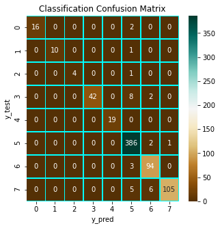

```python
rf_cm = confusion_matrix(y_test, y_pred_forest2)

# Visualization:
f, ax = plt.subplots(figsize=(5,5))
sns.heatmap(rf_cm, annot=True, linewidth=0.7, linecolor='cyan', fmt='.0f', ax=ax, cmap='BrBG')
plt.title('Classification Confusion Matrix')
plt.xlabel('y_pred')
plt.ylabel('y_test')
plt.show()
```

```python
print(classification_report(y_test, y_pred_forest2))
```

```
              precision    recall  f1-score   support

           0       1.00      0.89      0.94        18
           1       1.00      0.91      0.95        11
           2       1.00      0.80      0.89         5
           3       1.00      0.81      0.89        52
           4       1.00      1.00      1.00        19
           5       0.95      0.99      0.97       389
           6       0.90      0.97      0.94        97
           7       0.99      0.91      0.95       116

    accuracy                           0.96       707
   macro avg       0.98      0.91      0.94       707
weighted avg       0.96      0.96      0.96       707
```

# *Support vector classifier*

```python
support_vector = SVC( kernel = 'linear' )
support_vector.fit(X_train,y_train)
```

```
SVC(kernel='linear')
```

```python
y_test.shape
```

```
(707,)
```

```python
y_pred_svc=support_vector.predict(X_test)
print( "Test Accuracy : " , accuracy_score(y_pred_svc,y_test)*100)
ClassificationModels.append("Support Vector Classifier")
Accuracy.append(accuracy_score(y_pred_svc,y_test)*100)
```

```
Test Accuracy :  99.43422913719944
```

# *Naive Bayes*

```python
Naive = GaussianNB()
Naive.fit(X_train , y_train )
```

```
GaussianNB()
```

```python
NB_pred = Naive.predict(X_test)
```

```python
print( "Accuracy : " , accuracy_score(y_test,NB_pred)*100 , "%")
ClassificationModels.append("Naive Bayes")
Accuracy.append(accuracy_score(NB_pred,y_test)*100)
```

```
Accuracy :  95.04950495049505 %
```

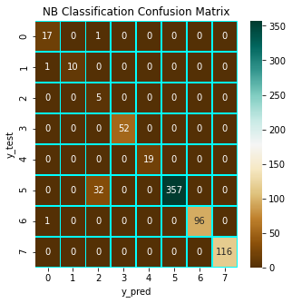

```python
# Creating the confusion matrix:
NB_cm = confusion_matrix(y_test, NB_pred)

# Visualization:
f, ax = plt.subplots(figsize=(5,5))
sns.heatmap(NB_cm, annot=True, linewidth=0.7, linecolor='cyan', fmt='.0f', ax=ax, cmap='BrBG')
plt.title('NB Classification Confusion Matrix')
plt.xlabel('y_pred')
plt.ylabel('y_test')
plt.show()
```

```python
print(classification_report(y_test, NB_pred))
```

```
              precision    recall  f1-score   support

           0       0.89      0.94      0.92        18
           1       1.00      0.91      0.95        11
           2       0.13      1.00      0.23         5
           3       1.00      1.00      1.00        52
           4       1.00      1.00      1.00        19
           5       1.00      0.92      0.96       389
           6       1.00      0.99      0.99        97
           7       1.00      1.00      1.00       116

    accuracy                           0.95       707
   macro avg       0.88      0.97      0.88       707
weighted avg       0.99      0.95      0.97       707
```

# XGB Classifier

```python
xgb=XGBClassifier()
```

```python
xgb.fit(X_train,y_train)
```

[output not shown]

```
XGBClassifier(base_score=0.5, booster='gbtree', colsample_bylevel=1,
              colsample_bynode=1, colsample_bytree=1, gamma=0, gpu_id=-1,
              importance_type='gain', interaction_constraints='',
              learning_rate=0.300000012, max_delta_step=0, max_depth=6,
              min_child_weight=1, missing=nan, monotone_constraints='()',
              n_estimators=100, n_jobs=4, num_parallel_tree=1,
              objective='multi:softprob', random_state=0, reg_alpha=0,
              reg_lambda=1, scale_pos_weight=None, subsample=1,
              tree_method='exact', validate_parameters=1, verbosity=None)
```

```python
pred=xgb.predict(X_test)
```

```python
cm=confusion_matrix(y_test,pred)
cm
```

```
array([[ 16,   0,   0,   0,   0,   1,   1,   0],
       [  0,  10,   0,   0,   0,   1,   0,   0],
       [  0,   0,   5,   0,   0,   0,   0,   0],
       [  0,   0,   0,  52,   0,   0,   0,   0],
       [  0,   0,   0,   0,  19,   0,   0,   0],
       [  0,   0,   0,   0,   0, 389,   0,   0],
       [  0,   0,   0,   0,   0,   0,  97,   0],
       [  0,   0,   0,   0,   0,   0,   3, 113]], dtype=int64)
```

```python
print( "Accuracy : " , accuracy_score(y_test,pred)*100 , "%" )
Accuracy.append(accuracy_score(y_test,pred)*100)
ClassificationModels.append("XGB Regressor")
```

```
Accuracy :  99.15134370579915 %
```

[figure not shown]

```python
rf_cm = confusion_matrix(y_test, pred)

# Visualization:
f, ax = plt.subplots(figsize=(5,5))
sns.heatmap(rf_cm, annot=True, linewidth=0.7, linecolor='cyan', fmt='.0f', ax=ax, cmap='BrBG')
plt.title('RF Classification Confusion Matrix')
plt.xlabel('y_pred')
plt.ylabel('y_test')
plt.show()
```

# LOGISTIC REGRESSION MODEL

```python
lrc = LogisticRegression( n_jobs = -1 , C = 0.1 , penalty = 'l2',    multi_class='auto' )
lrc.fit( X_train , y_train.ravel())
```

```
LogisticRegression(C=0.1, n_jobs=-1)
```

```python
y_pred_lrc = lrc.predict(X_test)
```

[figure not shown]

```python
rf_cm = confusion_matrix(y_test, y_pred_lrc)

# Visualization:
f, ax = plt.subplots(figsize=(5,5))
sns.heatmap(rf_cm, annot=True, linewidth=0.7, linecolor='cyan', fmt='.0f', ax=ax, cmap='BrBG')
plt.title('RF Classification Confusion Matrix')
plt.xlabel('y_pred')
plt.ylabel('y_test')
plt.show()
```

```python
print( "Accuracy : " , accuracy_score(y_test,y_pred_lrc)*100 , "%" )


ClassificationModels.append("Logistic Regression")
Accuracy.append(accuracy_score(y_test,y_pred_lrc)*100)
```

```
Accuracy :  57.14285714285714 %
```

### Accuracy of the models

```python
Classification_Models=pd.DataFrame(ClassificationModels)
Model_Accuracy=pd.DataFrame(Accuracy)

featurescores=pd.concat([Classification_Models,Model_Accuracy,],axis=1)
featurescores.columns=['Model_Name','Accuracy']
featurescores
```

|  | Model_Name | Accuracy |
| --- | --- | --- |
| 0 | Random Forest | 95.615276 |
| 1 | Support Vector Classifier | 99.434229 |
| 2 | Naive Bayes | 95.049505 |
| 3 | XGB Regressor | 99.151344 |
| 4 | Logistic Regression | 57.142857 |

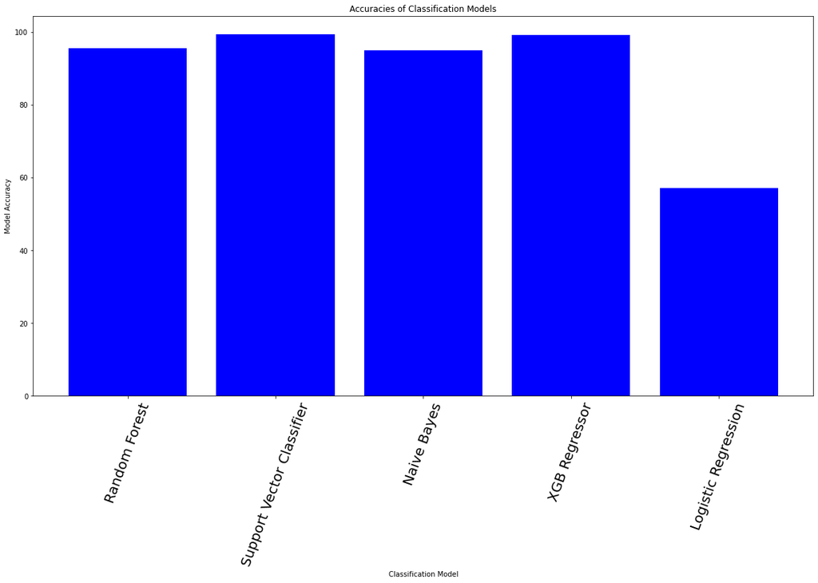

```python
Index = [1,2,3,4,5]
plt.figure(figsize=(20,10))
plt.bar(Index,Accuracy,color='b')
plt.xticks(Index, ClassificationModels,rotation=70,fontsize=20)
plt.ylabel('Model Accuracy')
plt.xlabel('Classification Model')
plt.title('Accuracies of Classification Models')
```

## *Store Result in Database*

```python
!pip install sqlalchemy
!pip install mysql
```

## *All Models Predicted Data*

```python
df1.index = dfff.index
df2.index = dfff.index
df3.index = dfff.index
df4.index = dfff.index
df5.index = dfff.index
df6.index = dfff.index
df7.index = dfff.index
df8.index = dfff.index
df9.index = dfff.index
df10.index = dfff.index
df11.index = dfff.index



v=pd.concat([dfff,df1,df2,df3,df4,df5,df6,df7,df8,df9,df10,df11],axis=1,ignore_index=False)
v.columns=['Actual','Linear Regression with Province','Linear Regression with City','Linear Regression with Travel_history','Linear Regression with Confirmed Cases','Multiple Linear Regression','Support Vector Regression','Ridge','Lasso','Random Forest','Decision Tree','XGBoost']
v
```

|  | Actual | Linear Regression with Province | Linear Regression with City | Linear Regression with Travel_history | Linear Regression with Confirmed Cases | Multiple Linear Regression | Support Vector Regression | Ridge | Lasso | Random Forest | Decision Tree | XGBoost |
| --- | --- | --- | --- | --- | --- | --- | --- | --- | --- | --- | --- | --- |
| 467 | 91 | 48.271777 | 1.875000 | 21.766197 | 2.100149 | 91.0 | -0.074343 | 90.999999 | 91.000776 | 89.68 | 83.0 | 91.851295 |
| 1674 | 2 | 6.896627 | 13.327590 | 21.766197 | 16.703275 | 2.0 | -0.187991 | 2.000000 | 1.999643 | 2.00 | 2.0 | 1.978243 |
| 917 | 5 | 6.896627 | 3.137373 | 21.766197 | 15.844268 | 5.0 | -0.177817 | 5.000000 | 4.999657 | 5.00 | 5.0 | 5.023557 |
| 1158 | 3 | 6.896627 | 1.672117 | 21.766197 | 5.536179 | 3.0 | -0.107560 | 3.000000 | 2.999648 | 3.00 | 3.0 | 2.991876 |
| 499 | 4 | 6.896627 | 3.000000 | 21.766197 | 6.395186 | 4.0 | -0.155567 | 4.000000 | 3.999653 | 4.00 | 4.0 | 3.963663 |
| ... | ... | ... | ... | ... | ... | ... | ... | ... | ... | ... | ... | ... |
| 2179 | 1 | 5.976471 | 3.034483 | 21.766197 | 0.382134 | 1.0 | -0.154648 | 1.000000 | 0.999638 | 1.00 | 1.0 | 0.999480 |
| 1542 | 1 | 6.896627 | 3.034483 | 21.766197 | 0.382134 | 1.0 | 2.979443 | 1.000000 | 0.999638 | 1.00 | 1.0 | 1.007973 |
| 393 | 4 | 2.285714 | 3.034483 | 21.766197 | 1.241142 | 4.0 | -0.189366 | 4.000000 | 3.999653 | 4.00 | 4.0 | 3.968160 |
| 1014 | 1 | 6.896627 | 3.034483 | 21.766197 | 5.536179 | 1.0 | -0.188003 | 1.000000 | 0.999638 | 1.00 | 1.0 | 0.995941 |
| 2060 | 40 | 6.896627 | 3.034483 | 21.766197 | 2.100149 | 40.0 | -0.207134 | 40.000000 | 39.999761 | 36.21 | 30.0 | 36.150059 |

707 rows × 12 columns

```python
from sqlalchemy import create_engine
engine = create_engine('mysql://root:root@localhost/predictions')
```

```python
v.to_sql('models_predictions_table', con=engine)
```

[output not shown]

[output cut: 250 more lines]

[output not shown]

## *All Models Evaluation*

```python
result_df.to_sql('Models_Evaluation_table', con=engine)
```

```python
result_df
```

|  | Model | MAE | MSE | RMSE | R2 Square | Train_Accuracy | Test_Accuracy |
| --- | --- | --- | --- | --- | --- | --- | --- |
| 0 | Linear Regression with Province | 2.501237e+01 | 5.223878e+03 | 7.227640e+01 | 4.393540e-02 | 0.059622 | 4.393540e-02 |
| 0 | Linear Regression with city | 1.093450e+12 | 1.056640e+26 | 1.027930e+13 | -2.152599e+22 | 0.291243 | -2.152599e+22 |
| 0 | Linear Regression with Travel_History | 2.759930e+01 | 4.938183e+03 | 7.027221e+01 | -6.011990e-03 | 0.003380 | -6.011990e-03 |
| 0 | Linear Regression with Confirmed_Cases | 3.957857e+00 | 5.488939e+02 | 2.342849e+01 | 9.347187e-01 | 0.688203 | 9.347187e-01 |
| 0 | Multiple Linear Regression | 1.408000e-06 | 3.485980e-10 | 1.867078e-05 | 1.000000e+00 | 1.000000 | 1.000000e+00 |
| 0 | Support Vector Regression Regression | 1.407921e-01 | 3.564569e-01 | 5.970401e-01 | 6.512993e-01 | 0.859803 | 6.512993e-01 |
| 0 | Ridge model | 1.667862e-07 | 2.156288e-13 | 4.643585e-07 | 1.000000e+00 | 1.000000 | 1.000000e+00 |
| 0 | LASSO model | 5.745902e-04 | 1.943357e-06 | 1.394044e-03 | 1.000000e+00 | 1.000000 | 1.000000e+00 |
| 0 | Random Forest model | 3.851513e+00 | 1.097147e+03 | 3.312321e+01 | 7.992022e-01 | 1.000000 | 7.992022e-01 |
| 0 | Decision tree model | 3.735502e+00 | 1.085396e+03 | 3.294535e+01 | 8.013528e-01 | 1.000000 | 8.013528e-01 |
| 0 | XGBRegressor model | 3.963043e+00 | 1.659700e+03 | 4.073942e+01 | 6.962447e-01 | 1.000000 | 6.962447e-01 |

## *STORE RESULT IN PICKLE FILE*

```python
import pickle
file3=open("ridge.pkl",'wb')
pickle.dump(lin,file3)
```

```python
X_test_confirmed.iloc[:,15:30]
```

|  | Travel_history_UK | Travel_history_USA | Travel_history_Unknown | Province_Baluchistan | Province_Federal_Administration_Tribal_Area | Province_Gilgit_Baltistan | Province_Islamabad_Capital_Territory | Province_Khyber_Pakhtunkhwa | Province_Punjab | Province_Sindh | City_Astore | City_Attock | City_Badin | City_Bahawal_Nagar | City_Bahawalpur |
| --- | --- | --- | --- | --- | --- | --- | --- | --- | --- | --- | --- | --- | --- | --- | --- |
| 467 | 0 | 0 | 1 | 0 | 0 | 0 | 0 | 0 | 0 | 1 | 0 | 0 | 0 | 0 | 0 |
| 1674 | 0 | 0 | 0 | 0 | 0 | 0 | 0 | 1 | 0 | 0 | 0 | 0 | 0 | 0 | 0 |
| 917 | 0 | 0 | 0 | 0 | 0 | 0 | 0 | 1 | 0 | 0 | 0 | 0 | 0 | 0 | 0 |
| 1158 | 0 | 0 | 0 | 0 | 0 | 0 | 0 | 1 | 0 | 0 | 0 | 0 | 0 | 0 | 0 |
| 499 | 0 | 0 | 0 | 0 | 0 | 0 | 0 | 1 | 0 | 0 | 0 | 0 | 0 | 0 | 0 |
| ... | ... | ... | ... | ... | ... | ... | ... | ... | ... | ... | ... | ... | ... | ... | ... |
| 2179 | 0 | 0 | 0 | 0 | 0 | 1 | 0 | 0 | 0 | 0 | 0 | 0 | 0 | 0 | 0 |
| 1542 | 0 | 0 | 0 | 0 | 0 | 0 | 0 | 1 | 0 | 0 | 0 | 0 | 0 | 0 | 0 |
| 393 | 0 | 0 | 0 | 0 | 1 | 0 | 0 | 0 | 0 | 0 | 0 | 0 | 0 | 0 | 0 |
| 1014 | 0 | 0 | 0 | 0 | 0 | 0 | 0 | 1 | 0 | 0 | 0 | 0 | 0 | 0 | 0 |
| 2060 | 0 | 0 | 0 | 0 | 0 | 0 | 0 | 1 | 0 | 0 | 0 | 0 | 0 | 0 | 0 |

707 rows × 15 columns